# Project Proposal & Preliminary Findings:

KKI Study on Motor Skills and Social Deficits in Children

Allison McCarty, Nick Mobley, Thomas Janes

11/13/2019

# Introduction: Study Details & Relevant Background Information

- Autism (ASD) and Attention Deficit/Hyperactivity Disorder (ADHD) are frequently observed in children, but are still not fully understood.
- Researchers at Kennedy Krieger Institute(KKI) ran a study on children with ASD, ADHD, and typically developing children to study differences in social deficits, motor impairment, intelligence.
  - It is known that children with developmental disorders suffer from motor impairment concurrent with social deficits associated with their respective diagnoses(1,2). The extent and cause of this correlation merits further research.
- Metrics and Scales Used to Quantify Symptom Severity in Children:
  1. Social Responsiveness Scale Questionnaire (SRS): measures severity of social deficits in children (higher scores indicate more social deficits)
  2. Movement Assessment Battery for Children (mABC): measures motor impairments in children. Three subcategories for assessment include dexterity, aiming and catching, and balance summed to obtain the mABC Total Standard Score
  3. Wechsler Intelligence Scale for Children (WISC): measures intelligence in children. Two versions of the test quantify vocabulary, information, picture concepts, etc.

# Introduction: Areas of Particular Interest

### Data and Analysis

- We want to investigate the overall association between social deficits and motor skills for each diagnosis group.

  > Primary Endpoint: What motor skills are associated with SRS scores for each diagnosis group.

  > Secondary Endpoint: What factors influence this association?
- Data Collected for Investigation and Analysis:
  - Age
  - Handedness (quantified by Edinburgh Handedness Integer)
  - Gender
  - Primary and Secondary Diagnosis
  - SRS Total and Subscores
  - mABC Total and Subscores
  - WISC Score

| Primary | Count | Avg Age | Males | Females | RightHanded | LeftHanded |
| --- | --- | --- | --- | --- | --- | --- |
| ASD | 135 | 10.165 | 113 | 22 | 124 | 20 |
| ADHD | 185 | 9.7308 | 129 | 56 | 285 | 36 |
| TD | 253 | 10.2219 | 184 | 69 | 307 | 42 |

# Relationship Between SRS Total Score and Motor Assessment Score

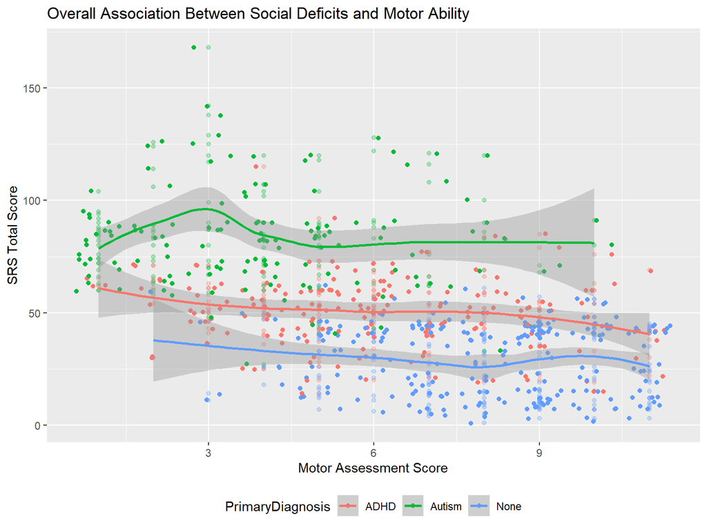

- Children with ASD tend to have the most social deficits and the lowest “high” score for motor assessment, followed by children with ADHD and TD children.
- For children with ASD, there is a slight increase in SRS score at low motor assessment scores, but the relationship is relatively constant at intermediate values of motor assessment
- There is a negative association between motor skills and SRS score in children with ADHD, meaning children with better motor skills tend to have less social deficits.
- Motor skills have little effect on social skills for typically-developing children.

*Scores above twelve for Typically Devloping children removed for readability.

# Relationship Between SRS Total Score and Motor Assessment Sub-Scores

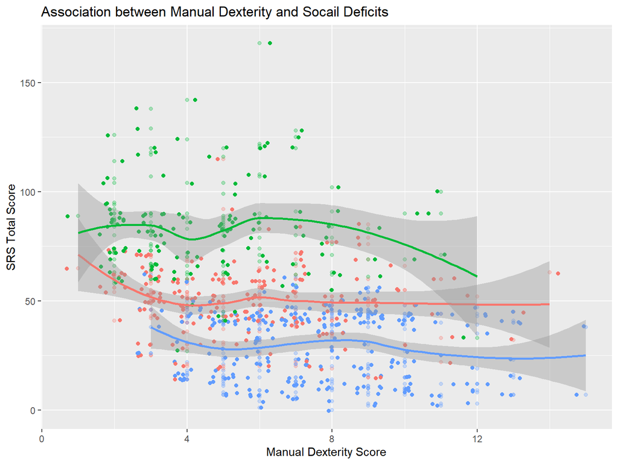

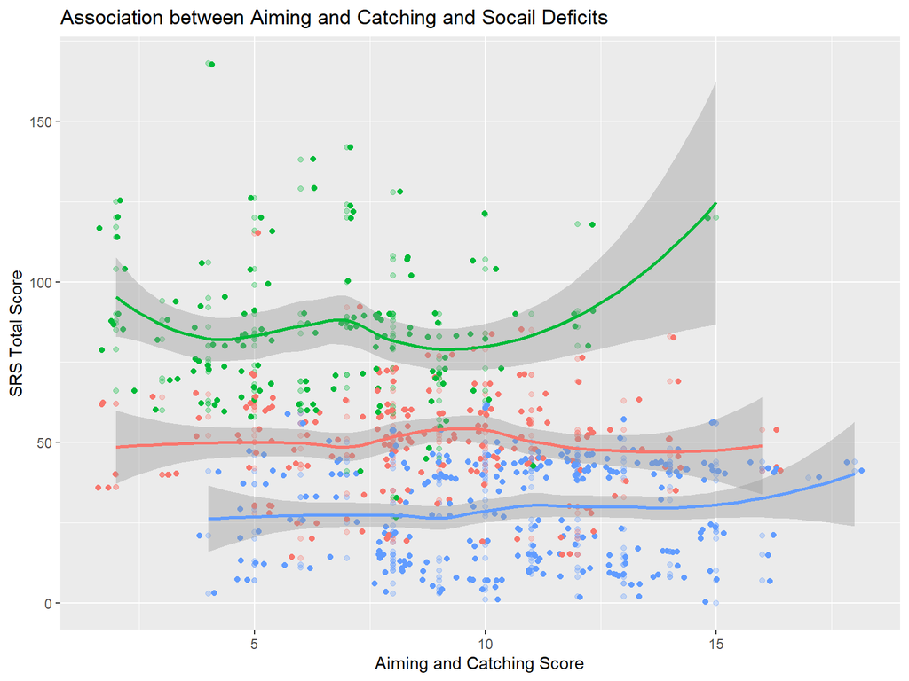

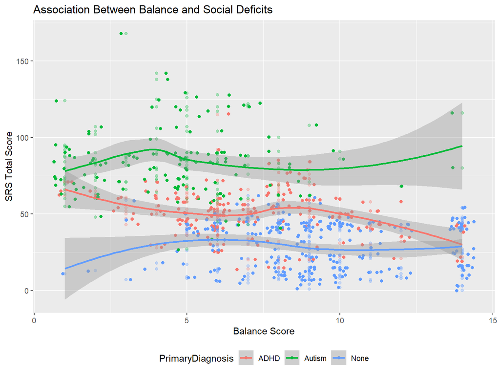

- The balance component of the motor assessment drives the negative correlation between social deficits and motor skills.
- For the ADS group, social deficits decreased as dexterity increased. Conversely, social deficits tended to increase as aiming and catching ability increased. *Balance Scores above 15 for Typically Devloping children removed for readability.

# Does Intelligence(measured by WISC) influence Social Deficits or Motor Skills?

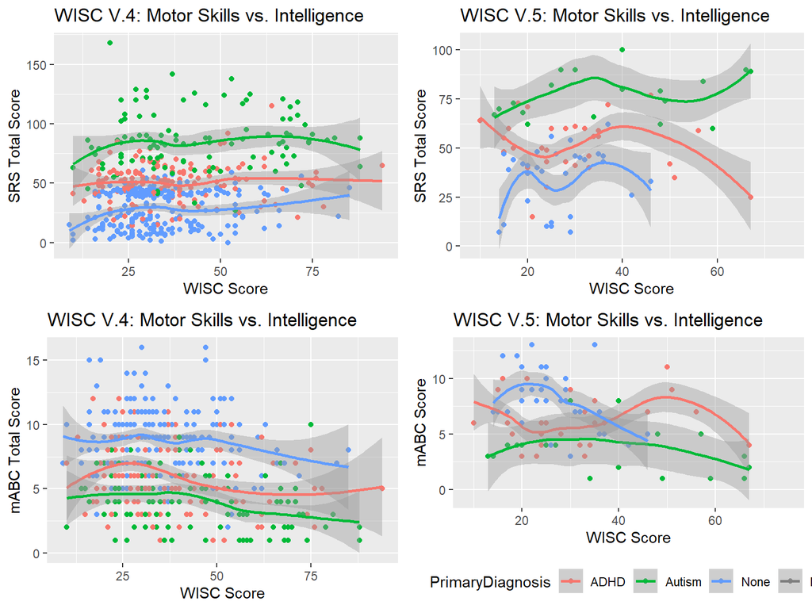

- There is no substantial correlation between intelligence and social deficits in children across all subgroups.
- There is a slight negative relationship between intelligence and motor skills in children across all subgroups, but the correlation is small and likely negligible.

# Does having multiple diagnoses influence Social Deficits or Motor Skills?

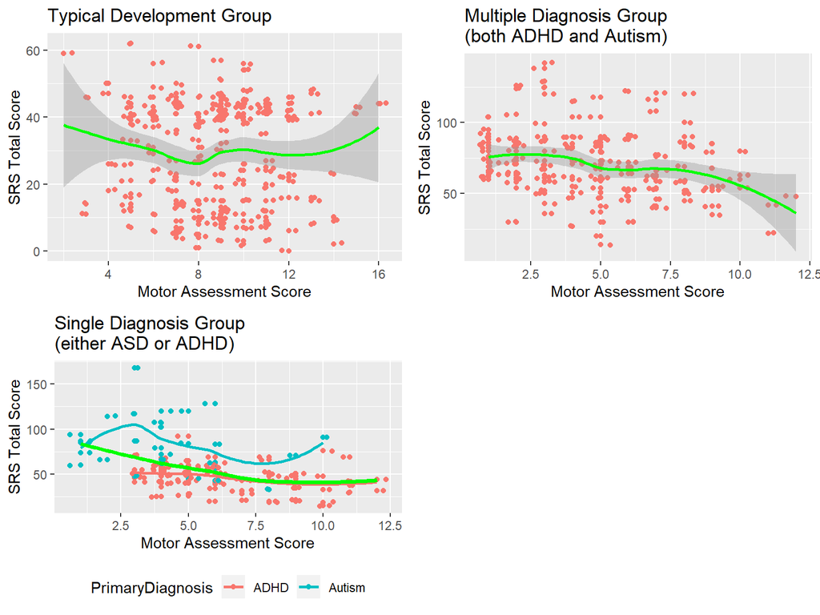

# Does Handedness influence Social Deficits or Motor Skills?

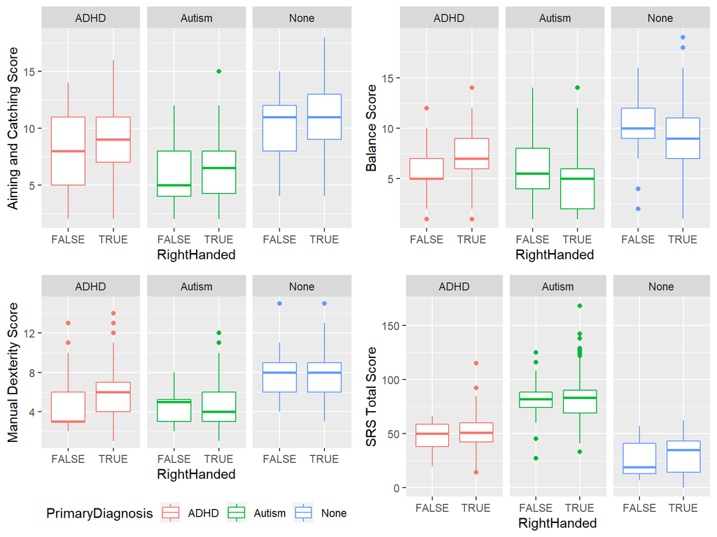

- Depending on our test the being Right handed correlates to difference in performance on motor skills
- However we find no correlation between handeness and scoial deficit for ADHD and Autism

| Primary | Right | SD | Left | SD |
| --- | --- | --- | --- | --- |
| ASD | 124 | 2.1778 | 20 | 2.3368 |
| ADHD | 285 | 2.7124 | 36 | 2.8329 |
| TD | 307 | 2.4831 | 42 | 2.5326 |

# Does Age influence Social Deficits or Motor Skills?

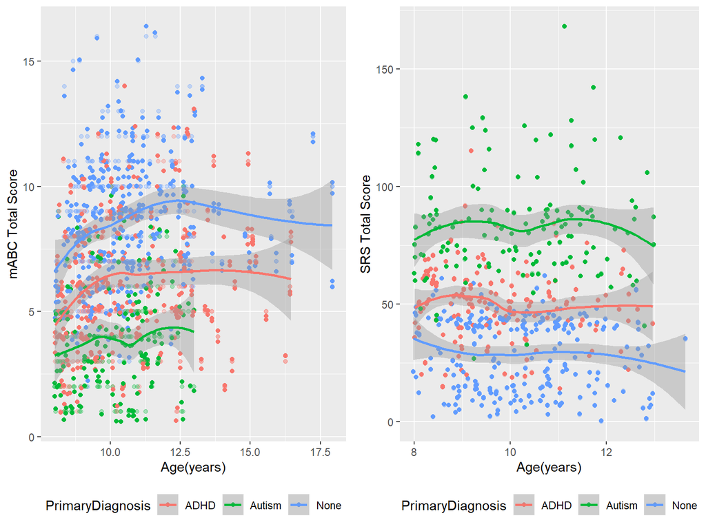

- Age did not seem to have a substantial effect on SRS assessment for any of the diagnosis groups.
- For all groups, motor ability tended to increase until about age 10 or 12, and then plateau.

# Summary of Preliminary and Research Proposal

- The overall relationship will be most effectively studied by stratifying for each diagnosis group, and investigating the motor assessment subcomponenets, rather than the total overall score.
- Intelligence
- The number of diagnoses that a child has (0, 1, or 2) affect the relationship between motor ability and social deficits.
- Handedness
- Age influences motor abilities, but it does not influence SRS score.
- Research Proposal: We want to invesitate how social deficits and specific motor skills (mABC sub-components) differ in children with ASD, ADHD and TD groups We want to understand the relationship between social deficits and motor skills, and how factors such as intelligence, age, handedness, and having a second diagnosis affect this relationsip for each of the groups.

# Citations

1. Green, D., Charman, T., Pickles, A., Chandler, S., Loucas, T.,Simonoff, E., et al. (2009). Impairment in movement skills ofchildren with autistic spectrum disorders. Developmental Medicine and Child Neurology, 51(4), 311–316.
2. Ament, K., Mejia, A., E., et al. (2014). Evidence for specificity of motor impairments in catching and balance in children with autism. Journal of autism and developmental disorders, 45(3), pp.742-751.